# Logistic Regression homework

```r
library(tidyverse)
library(modelr)
#library(janitor)
```

```r
orange_juice <- read_csv("data/orange_juice.csv") %>%
  janitor::clean_names()
```

```r
glimpse(orange_juice)
```

```
Rows: 1,070
Columns: 18
$ purchase        <chr> "CH", "CH", "CH", "MM", "CH", "CH", "CH", "CH", "CH", "CH", "CH", "CH", "CH", "CH", "CH", "CH", "MM…
$ weekof_purchase <dbl> 237, 239, 245, 227, 228, 230, 232, 234, 235, 238, 240, 263, 276, 268, 278, 278, 240, 268, 269, 254,…
$ store_id        <dbl> 1, 1, 1, 1, 7, 7, 7, 7, 7, 7, 7, 7, 7, 7, 7, 7, 1, 2, 2, 7, 7, 1, 7, 7, 7, 7, 7, 7, 7, 7, 2, 7, 2, …
$ price_ch        <dbl> 1.75, 1.75, 1.86, 1.69, 1.69, 1.69, 1.69, 1.75, 1.75, 1.75, 1.86, 1.86, 1.99, 1.86, 2.06, 2.06, 1.7…
$ price_mm        <dbl> 1.99, 1.99, 2.09, 1.69, 1.69, 1.99, 1.99, 1.99, 1.99, 1.99, 2.09, 2.13, 2.13, 2.13, 2.13, 2.13, 1.9…
$ disc_ch         <dbl> 0.00, 0.00, 0.17, 0.00, 0.00, 0.00, 0.00, 0.00, 0.00, 0.00, 0.00, 0.27, 0.00, 0.00, 0.00, 0.00, 0.0…
$ disc_mm         <dbl> 0.00, 0.30, 0.00, 0.00, 0.00, 0.00, 0.40, 0.40, 0.40, 0.40, 0.00, 0.00, 0.54, 0.00, 0.00, 0.00, 0.3…
$ special_ch      <dbl> 0, 0, 0, 0, 0, 0, 1, 1, 0, 0, 0, 0, 0, 0, 0, 0, 0, 0, 0, 0, 0, 0, 0, 1, 0, 1, 0, 0, 1, 0, 0, 1, 0, …
$ special_mm      <dbl> 0, 1, 0, 0, 0, 1, 1, 0, 0, 0, 0, 0, 1, 0, 0, 0, 1, 1, 0, 0, 0, 0, 0, 0, 0, 0, 0, 0, 0, 0, 0, 0, 1, …
$ loyal_ch        <dbl> 0.500000, 0.600000, 0.680000, 0.400000, 0.956535, 0.965228, 0.972182, 0.977746, 0.982197, 0.985757,…
$ sale_price_mm   <dbl> 1.99, 1.69, 2.09, 1.69, 1.69, 1.99, 1.59, 1.59, 1.59, 1.59, 2.09, 2.13, 1.59, 2.13, 2.13, 2.13, 1.6…
$ sale_price_ch   <dbl> 1.75, 1.75, 1.69, 1.69, 1.69, 1.69, 1.69, 1.75, 1.75, 1.75, 1.86, 1.59, 1.99, 1.86, 2.06, 2.06, 1.7…
$ price_diff      <dbl> 0.24, -0.06, 0.40, 0.00, 0.00, 0.30, -0.10, -0.16, -0.16, -0.16, 0.23, 0.54, -0.40, 0.27, 0.07, 0.0…
$ store7          <chr> "No", "No", "No", "No", "Yes", "Yes", "Yes", "Yes", "Yes", "Yes", "Yes", "Yes", "Yes", "Yes", "Yes"…
$ pct_disc_mm     <dbl> 0.000000, 0.150754, 0.000000, 0.000000, 0.000000, 0.000000, 0.201005, 0.201005, 0.201005, 0.201005,…
$ pct_disc_ch     <dbl> 0.000000, 0.000000, 0.091398, 0.000000, 0.000000, 0.000000, 0.000000, 0.000000, 0.000000, 0.000000,…
$ list_price_diff <dbl> 0.24, 0.24, 0.23, 0.00, 0.00, 0.30, 0.30, 0.24, 0.24, 0.24, 0.23, 0.27, 0.14, 0.27, 0.07, 0.07, 0.2…
$ store           <dbl> 1, 1, 1, 1, 0, 0, 0, 0, 0, 0, 0, 0, 0, 0, 0, 0, 1, 2, 2, 0, 0, 1, 0, 0, 0, 0, 0, 0, 0, 0, 2, 0, 2, …
```

```r
skimr::skim(orange_juice)
```

```
── Data Summary ────────────────────────
                           Values
Name                       orange_juice
Number of rows             1070
Number of columns          18
_______________________
Column type frequency:
  character                2
  numeric                  16
________________________
Group variables            None
```

|  | skim_variable | n_missing | complete_rate | min | max | empty | n_unique | whitespace |
| --- | --- | --- | --- | --- | --- | --- | --- | --- |
| 1 | purchase | 0 | 1 | 2 | 2 | 0 | 2 | 0 |
| 2 | store7 | 0 | 1 | 2 | 3 | 0 | 2 | 0 |

|  | skim_variable | n_missing | complete_rate | mean | sd | p0 | p25 | p50 | p75 | p100 | hist |
| --- | --- | --- | --- | --- | --- | --- | --- | --- | --- | --- | --- |
| 1 | weekof_purchase | 0 | 1 | 254.38130841 | 15.5582861 | 2.27e+02 | 240.0000000 | 257.00 | 268.0000000 | 278.000000 | ▆▅▅▇▇ |
| 2 | store_id | 0 | 1 | 3.95981308 | 2.3089835 | 1.00e+00 | 2.0000000 | 3.00 | 7.0000000 | 7.000000 | ▇▅▃▁▇ |
| 3 | price_ch | 0 | 1 | 1.86742056 | 0.1019698 | 1.69e+00 | 1.7900000 | 1.86 | 1.9900000 | 2.090000 | ▅▂▇▆▁ |
| 4 | price_mm | 0 | 1 | 2.08541121 | 0.1343855 | 1.69e+00 | 1.9900000 | 2.09 | 2.1800000 | 2.290000 | ▂▁▃▇▆ |
| 5 | disc_ch | 0 | 1 | 0.05185981 | 0.1174742 | 0.00e+00 | 0.0000000 | 0.00 | 0.0000000 | 0.500000 | ▇▁▁▁▁ |
| 6 | disc_mm | 0 | 1 | 0.12336449 | 0.2138337 | 0.00e+00 | 0.0000000 | 0.00 | 0.2300000 | 0.800000 | ▇▁▂▁▁ |
| 7 | special_ch | 0 | 1 | 0.14766355 | 0.3549321 | 0.00e+00 | 0.0000000 | 0.00 | 0.0000000 | 1.000000 | ▇▁▁▁▂ |
| 8 | special_mm | 0 | 1 | 0.16168224 | 0.3683312 | 0.00e+00 | 0.0000000 | 0.00 | 0.0000000 | 1.000000 | ▇▁▁▁▂ |
| 9 | loyal_ch | 0 | 1 | 0.56578233 | 0.3078425 | 1.10e-05 | 0.3252572 | 0.60 | 0.8508728 | 0.999947 | ▅▃▆▆▇ |
| 10 | sale_price_mm | 0 | 1 | 1.96204673 | 0.2526974 | 1.19e+00 | 1.6900000 | 2.09 | 2.1300000 | 2.290000 | ▁▂▂▂▇ |

[output cut: 6 more lines]

```r
orange_juice %>%
  distinct(store_id)
```

| store_id |
| --- |
| 1 |
| 7 |
| 2 |
| 3 |
| 4 |

```r
orange_index <- sample(1:nrow(orange_juice), size = nrow(orange_juice)*0.2)

# Use the test index to create test and training datasets
test  <- slice(orange_juice, orange_index)
train <- slice(orange_juice, -orange_index)
```

## Wrangling Data and Feature engineering

```r
orange_tidy <- orange_juice %>%
  mutate(special_ch = as.logical(special_ch)) %>%
  mutate(special_mm = as.logical(special_mm)) %>%
  mutate(store7 = store7 == "Yes") %>%
  mutate(store = as.factor(store)) %>%
  mutate(store_id = as.factor(store_id)) %>%
  mutate(purchase_mm = purchase == "MM") %>% #I need the purchase variable to be two-categorical for applying logist. regr.
  select(-purchase)

orange_tidy
```

| weekof_purchase | store_id | price_ch | price_mm | disc_ch | disc_mm | special_ch | special_mm | loyal_ch | sale_price_mm | sale_price_ch | price_diff | store7 | pct_disc_mm | pct_disc_ch | list_price_diff | store | purchase_mm |
| --- | --- | --- | --- | --- | --- | --- | --- | --- | --- | --- | --- | --- | --- | --- | --- | --- | --- |
| 237 | 1 | 1.75 | 1.99 | 0.00 | 0.00 | FALSE | FALSE | 0.500000 | 1.99 | 1.75 | 0.24 | FALSE | 0.000000 | 0.000000 | 0.24 | 1 | FALSE |
| 239 | 1 | 1.75 | 1.99 | 0.00 | 0.30 | FALSE | TRUE | 0.600000 | 1.69 | 1.75 | -0.06 | FALSE | 0.150754 | 0.000000 | 0.24 | 1 | FALSE |
| 245 | 1 | 1.86 | 2.09 | 0.17 | 0.00 | FALSE | FALSE | 0.680000 | 2.09 | 1.69 | 0.40 | FALSE | 0.000000 | 0.091398 | 0.23 | 1 | FALSE |
| 227 | 1 | 1.69 | 1.69 | 0.00 | 0.00 | FALSE | FALSE | 0.400000 | 1.69 | 1.69 | 0.00 | FALSE | 0.000000 | 0.000000 | 0.00 | 1 | TRUE |
| 228 | 7 | 1.69 | 1.69 | 0.00 | 0.00 | FALSE | FALSE | 0.956535 | 1.69 | 1.69 | 0.00 | TRUE | 0.000000 | 0.000000 | 0.00 | 0 | FALSE |
| 230 | 7 | 1.69 | 1.99 | 0.00 | 0.00 | FALSE | TRUE | 0.965228 | 1.99 | 1.69 | 0.30 | TRUE | 0.000000 | 0.000000 | 0.30 | 0 | FALSE |
| 232 | 7 | 1.69 | 1.99 | 0.00 | 0.40 | TRUE | TRUE | 0.972182 | 1.59 | 1.69 | -0.10 | TRUE | 0.201005 | 0.000000 | 0.30 | 0 | FALSE |
| 234 | 7 | 1.75 | 1.99 | 0.00 | 0.40 | TRUE | FALSE | 0.977746 | 1.59 | 1.75 | -0.16 | TRUE | 0.201005 | 0.000000 | 0.24 | 0 | FALSE |
| 235 | 7 | 1.75 | 1.99 | 0.00 | 0.40 | FALSE | FALSE | 0.982197 | 1.59 | 1.75 | -0.16 | TRUE | 0.201005 | 0.000000 | 0.24 | 0 | FALSE |
| 238 | 7 | 1.75 | 1.99 | 0.00 | 0.40 | FALSE | FALSE | 0.985757 | 1.59 | 1.75 | -0.16 | TRUE | 0.201005 | 0.000000 | 0.24 | 0 | FALSE |

[output cut: 990 more lines]

```r
orange_tidy %>%
  group_by(weekof_purchase) %>%
  summarise(sum = n())
```

| weekof_purchase | sum |
| --- | --- |
| 227 | 15 |
| 228 | 22 |
| 229 | 23 |
| 230 | 19 |
| 231 | 20 |
| 232 | 19 |
| 233 | 28 |
| 234 | 18 |
| 235 | 16 |
| 236 | 23 |

[output cut: 42 more lines]

`weekof_purchase` could be converted as a factor, but this would lead to many labels, so I don’t think it would be a good idea.

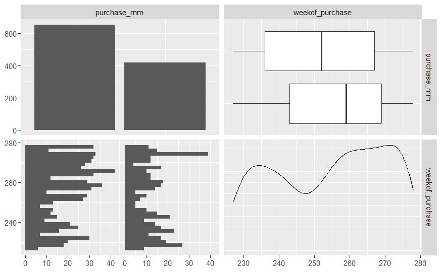

```r
library(GGally)
orange_tidy %>%
select(purchase_mm, weekof_purchase) %>%
ggpairs(progress = FALSE)
```

From the ggpairs plot, it seems that `weekof_purchase` has a certain incidence on the purchase.

For this reason, for now I will turn it into a factor, even if the labels will be many.

```r
orange_tidy <- orange_tidy %>%
  mutate(weekof_purchase_fac = as.factor(weekof_purchase))
```

Check for aliased variables

```r
alias(purchase_mm ~., data = orange_tidy)
```

```
Model :
purchase_mm ~ weekof_purchase + store_id + price_ch + price_mm +
    disc_ch + disc_mm + special_ch + special_mm + loyal_ch +
    sale_price_mm + sale_price_ch + price_diff + store7 + pct_disc_mm +
    pct_disc_ch + list_price_diff + store + weekof_purchase_fac

Complete :
                       (Intercept) weekof_purchase store_id2 store_id3 store_id4 store_id7 price_ch price_mm disc_ch disc_mm
sale_price_mm                0           0               0         0         0         0         0        1        0      -1
sale_price_ch                0           0               0         0         0         0         1        0       -1       0
price_diff                   0           0               0         0         0         0        -1        1        1      -1
store7TRUE                   0           0               0         0         0         1         0        0        0       0
list_price_diff              0           0               0         0         0         0        -1        1        0       0
store1                       1           0              -1        -1        -1        -1         0        0        0       0
store2                       0           0               1         0         0         0         0        0        0       0
store3                       0           0               0         1         0         0         0        0        0       0
store4                       0           0               0         0         1         0         0        0        0       0
weekof_purchase_fac278 -227/51        1/51               0         0         0         0         0        0        0       0
                       special_chTRUE special_mmTRUE loyal_ch pct_disc_mm pct_disc_ch weekof_purchase_fac228
sale_price_mm                0              0              0        0           0           0
sale_price_ch                0              0              0        0           0           0
price_diff                   0              0              0        0           0           0
store7TRUE                   0              0              0        0           0           0
list_price_diff              0              0              0        0           0           0
store1                       0              0              0        0           0           0
store2                       0              0              0        0           0           0
store3                       0              0              0        0           0           0
store4                       0              0              0        0           0           0
weekof_purchase_fac278       0              0              0        0           0       -1/51
                       weekof_purchase_fac229 weekof_purchase_fac230 weekof_purchase_fac231 weekof_purchase_fac232
sale_price_mm                0                      0                      0                      0
sale_price_ch                0                      0                      0                      0
price_diff                   0                      0                      0                      0
store7TRUE                   0                      0                      0                      0
list_price_diff              0                      0                      0                      0
store1                       0                      0                      0                      0
store2                       0                      0                      0                      0
store3                       0                      0                      0                      0
store4                       0                      0                      0                      0
weekof_purchase_fac278   -2/51                  -1/17                  -4/51                  -5/51
```

[output cut: 117 more lines]

```
store2                       0                      0                      0                      0
store3                       0                      0                      0                      0
store4                       0                      0                      0                      0
weekof_purchase_fac278  -46/51                 -47/51                 -16/17                 -49/51
                       weekof_purchase_fac277
sale_price_mm                0
sale_price_ch                0
price_diff                   0
store7TRUE                   0
list_price_diff              0
store1                       0
store2                       0
store3                       0
store4                       0
weekof_purchase_fac278  -50/51
```

from the alias function we can deduce that the variables “sale_price_mm”, “sale_price_ch”, “price_diff”, “store7”, “list_price_diff”, “store” can be derived from the other variables, for this reason we can delete them.

Of course also weekof_purchese is dependent from its factorial version!

```r
orange_tidy <- orange_tidy %>%
  select(-c("sale_price_mm", "sale_price_ch", "price_diff", "store7", "list_price_diff", "store", "weekof_purchase_fac"))
```

```r
glimpse(orange_tidy)
```

```
Rows: 1,070
Columns: 12
$ weekof_purchase <dbl> 237, 239, 245, 227, 228, 230, 232, 234, 235, 238, 240, 263, 276, 268, 278, 278, 240, 268, 269, 254,…
$ store_id        <fct> 1, 1, 1, 1, 7, 7, 7, 7, 7, 7, 7, 7, 7, 7, 7, 7, 1, 2, 2, 7, 7, 1, 7, 7, 7, 7, 7, 7, 7, 7, 2, 7, 2, …
$ price_ch        <dbl> 1.75, 1.75, 1.86, 1.69, 1.69, 1.69, 1.69, 1.75, 1.75, 1.75, 1.86, 1.86, 1.99, 1.86, 2.06, 2.06, 1.7…
$ price_mm        <dbl> 1.99, 1.99, 2.09, 1.69, 1.69, 1.99, 1.99, 1.99, 1.99, 1.99, 2.09, 2.13, 2.13, 2.13, 2.13, 2.13, 1.9…
$ disc_ch         <dbl> 0.00, 0.00, 0.17, 0.00, 0.00, 0.00, 0.00, 0.00, 0.00, 0.00, 0.00, 0.27, 0.00, 0.00, 0.00, 0.00, 0.0…
$ disc_mm         <dbl> 0.00, 0.30, 0.00, 0.00, 0.00, 0.00, 0.40, 0.40, 0.40, 0.40, 0.00, 0.00, 0.54, 0.00, 0.00, 0.00, 0.3…
$ special_ch      <lgl> FALSE, FALSE, FALSE, FALSE, FALSE, FALSE, TRUE, TRUE, FALSE, FALSE, FALSE, FALSE, FALSE, FALSE, FAL…
$ special_mm      <lgl> FALSE, TRUE, FALSE, FALSE, FALSE, TRUE, TRUE, FALSE, FALSE, FALSE, FALSE, FALSE, TRUE, FALSE, FALSE…
$ loyal_ch        <dbl> 0.500000, 0.600000, 0.680000, 0.400000, 0.956535, 0.965228, 0.972182, 0.977746, 0.982197, 0.985757,…
$ pct_disc_mm     <dbl> 0.000000, 0.150754, 0.000000, 0.000000, 0.000000, 0.000000, 0.201005, 0.201005, 0.201005, 0.201005,…
$ pct_disc_ch     <dbl> 0.000000, 0.000000, 0.091398, 0.000000, 0.000000, 0.000000, 0.000000, 0.000000, 0.000000, 0.000000,…
$ purchase_mm     <lgl> FALSE, FALSE, FALSE, TRUE, FALSE, FALSE, FALSE, FALSE, FALSE, FALSE, FALSE, FALSE, FALSE, FALSE, FA…
```

```r
orange_num <- orange_tidy %>%
  select_if(is.numeric)

orange_num$purchase_mm <- orange_tidy$purchase_mm


orange_cat <- orange_tidy %>%
  select_if(function(x) !is.numeric(x))
```

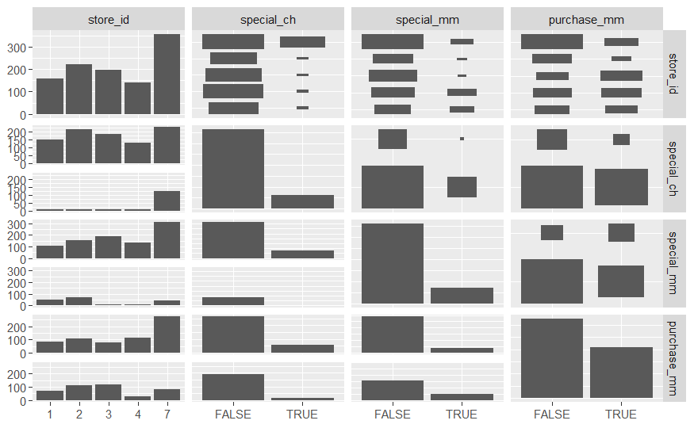

```r
ggpairs(orange_cat, progress = FALSE)
```

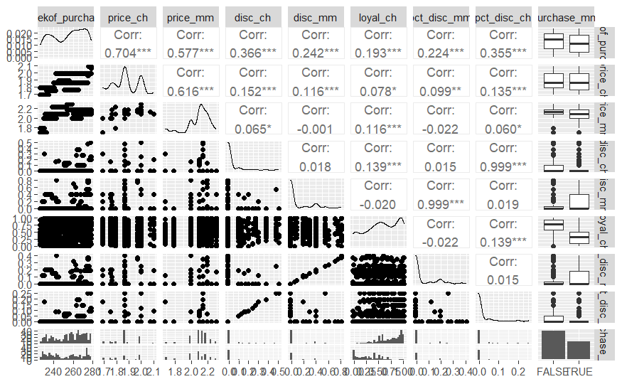

```r
ggpairs(orange_num, progress = FALSE)
```

It seems that there is an interesting relationship between `purchase_mm` and `weekof_purchase`, `store_id`, `loyal_ch`, `price_ch` , `price_mm`, `disc_mm` and `pct_disc_ch`.

## Train and test sets set up and model’s construction

Let’s construct the train and test sets

```r
set.seed(42)


orange_index <- sample(1:nrow(orange_tidy), size = nrow(orange_tidy)*0.2)

test  <- slice(orange_tidy, orange_index)
train <- slice(orange_tidy, -orange_index)
```

I want to verify if the division into train and test sets is proportionate.

```r
#library(modelr)
library(janitor)
train %>%
  tabyl(purchase_mm)
```

```
 purchase_mm   n   percent
       FALSE 531 0.6203271
        TRUE 325 0.3796729
```

```r
test %>%
  tabyl(purchase_mm)
```

```
 purchase_mm   n   percent
       FALSE 122 0.5700935
        TRUE  92 0.4299065
```

```r
orange_index <- sample(1:nrow(orange_tidy), size = nrow(orange_tidy)*0.2)

test  <- slice(orange_tidy, orange_index)
train <- slice(orange_tidy, -orange_index)


train %>%
  tabyl(purchase_mm)
```

```
 purchase_mm   n   percent
       FALSE 522 0.6098131
        TRUE 334 0.3901869
```

```r
test %>%
  tabyl(purchase_mm)
```

```
 purchase_mm   n   percent
       FALSE 131 0.6121495
        TRUE  83 0.3878505
```

This seems to be better!

Now, I am ready for setting up the predictive models.

```r
summary(model_1)
```

```
Call:
glm(formula = purchase_mm ~ ., family = binomial(link = "logit"),
    data = train)

Coefficients:
                 Estimate Std. Error z value Pr(>|z|)
(Intercept)       4.54164    2.36146   1.923  0.05445 .
weekof_purchase  -0.01242    0.01273  -0.976  0.32926
store_id2         0.02485    0.31613   0.079  0.93735
store_id3        -0.28303    0.43269  -0.654  0.51304
store_id4        -0.81776    0.46890  -1.744  0.08116 .
store_id7        -0.81522    0.32740  -2.490  0.01277 *
price_ch          4.33135    2.11888   2.044  0.04094 *
price_mm         -3.18005    1.03642  -3.068  0.00215 **
disc_ch           5.33780   22.08247   0.242  0.80900
disc_mm          16.95490   10.64231   1.593  0.11112
special_chTRUE    0.08851    0.38345   0.231  0.81746
special_mmTRUE    0.14142    0.31451   0.450  0.65297
loyal_ch         -6.07186    0.44975 -13.500  < 2e-16 ***
pct_disc_mm     -29.60969   22.25979  -1.330  0.18346
pct_disc_ch     -17.58499   41.51181  -0.424  0.67185
---
Signif. codes:  0 ‘***’ 0.001 ‘**’ 0.01 ‘*’ 0.05 ‘.’ 0.1 ‘ ’ 1

(Dispersion parameter for binomial family taken to be 1)

    Null deviance: 1145.04  on 855  degrees of freedom
Residual deviance:  651.46  on 841  degrees of freedom
AIC: 681.46

Number of Fisher Scoring iterations: 5
```

```r
summary(model_2)
```

```
Call:
glm(formula = purchase_mm ~ weekof_purchase + store_id + loyal_ch,
    family = binomial(link = "logit"), data = train)

Coefficients:
                 Estimate Std. Error z value Pr(>|z|)
(Intercept)      3.468720   1.495293   2.320   0.0204 *
weekof_purchase -0.001646   0.005928  -0.278   0.7813
store_id2        0.011142   0.281139   0.040   0.9684
store_id3       -0.351691   0.311051  -1.131   0.2582
store_id4       -0.612293   0.361226  -1.695   0.0901 .
store_id7       -1.084861   0.274804  -3.948 7.89e-05 ***
loyal_ch        -5.812764   0.416808 -13.946  < 2e-16 ***
---
Signif. codes:  0 ‘***’ 0.001 ‘**’ 0.01 ‘*’ 0.05 ‘.’ 0.1 ‘ ’ 1

(Dispersion parameter for binomial family taken to be 1)

    Null deviance: 1145.04  on 855  degrees of freedom
Residual deviance:  723.75  on 849  degrees of freedom
AIC: 737.75

Number of Fisher Scoring iterations: 5
```

The residual deviance id higher in model_2 than in model_1

```r
summary(model_3)
```

```
Call:
glm(formula = purchase_mm ~ price_ch + price_mm + disc_mm + loyal_ch +
    pct_disc_ch, family = binomial(link = "logit"), data = train)

Coefficients:
            Estimate Std. Error z value Pr(>|z|)
(Intercept)   3.5810     1.7839   2.007  0.04471 *
price_ch      3.1320     1.2785   2.450  0.01430 *
price_mm     -3.2555     0.9086  -3.583  0.00034 ***
disc_mm       2.7674     0.4641   5.962 2.48e-09 ***
loyal_ch     -6.2519     0.4282 -14.602  < 2e-16 ***
pct_disc_ch  -9.2901     1.9411  -4.786 1.70e-06 ***
---
Signif. codes:  0 ‘***’ 0.001 ‘**’ 0.01 ‘*’ 0.05 ‘.’ 0.1 ‘ ’ 1

(Dispersion parameter for binomial family taken to be 1)

    Null deviance: 1145.0  on 855  degrees of freedom
Residual deviance:  668.5  on 850  degrees of freedom
AIC: 680.5

Number of Fisher Scoring iterations: 5
```

```r
auc(model_3)
```

```
Error in roc.default(response, predictor, auc = TRUE, ...) :
  No valid data provided.
```

```r
roc_3 <- test %>%
  add_predictions(model_3, type = "response") %>%
  roc(response = purchase_mm, predictor = pred)
```

```r
auc(roc_3)
```

```
Area under the curve: 0.8952
```

```r
roc_1 <- test %>%
  add_predictions(model_1, type = "response") %>%
  roc(response = purchase_mm, predictor = pred)
auc(roc_1)
```

```
Area under the curve: 0.8966
```

```r
roc_2 <- test %>%
  add_predictions(model_2, type = "response") %>%
  roc(response = purchase_mm, predictor = pred)
auc(roc_2)
```

```
Area under the curve: 0.8841
```

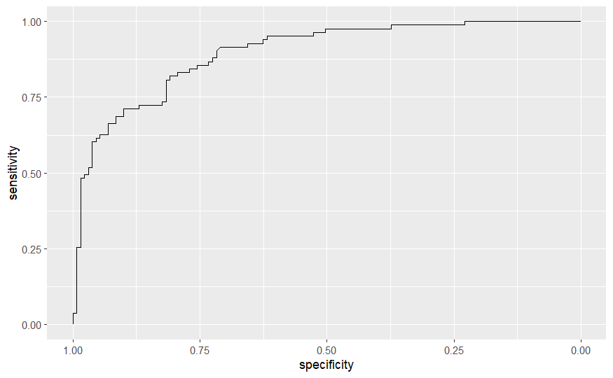

```r
model_1_pred <- test %>%
  add_predictions(model_1, type = "response") %>%
  mutate(odds = pred / (1 - pred))

roc_obj_1 <- model_1_pred %>%
  roc(response = purchase_mm,
      predictor = pred)
ggroc(roc_obj_1)
```

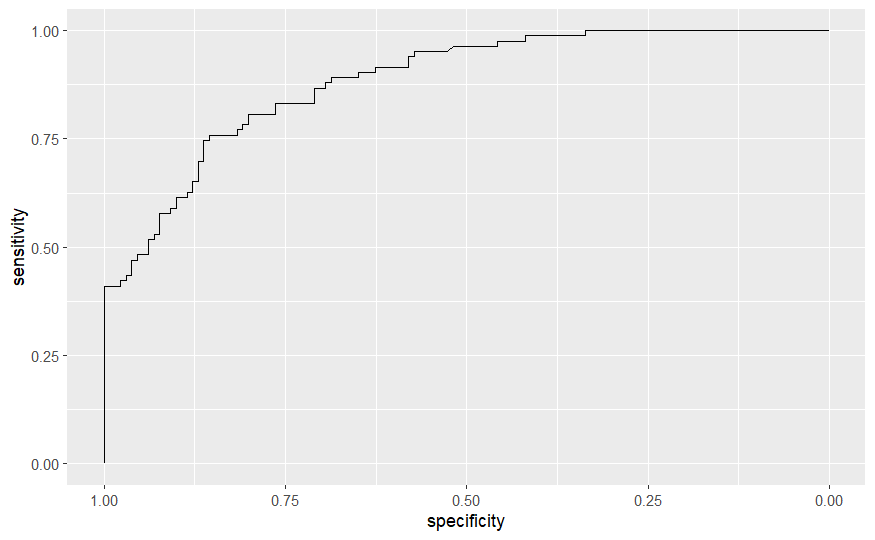

```r
model_2_pred <- test %>%
  add_predictions(model_2, type = "response") %>%
  mutate(odds = pred / (1 - pred))

roc_obj_2 <- model_2_pred %>%
  roc(response = purchase_mm,
      predictor = pred)
ggroc(roc_obj_2)
```

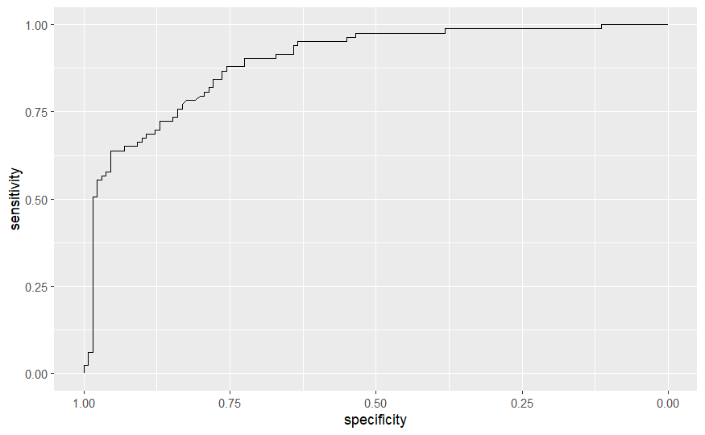

```r
model_3_pred <- test %>%
  add_predictions(model_3, type = "response") %>%
  mutate(odds = pred / (1 - pred))

roc_obj_3 <- model_3_pred %>%
  roc(response = purchase_mm,
      predictor = pred)
ggroc(roc_obj_3)
```